# Assignment4

Tianran Zhang

7/21/2020

# 1.

## Data Description

We have data on viral load for the first few weeks of infection for a certain infectious disease. An antiviral treatment “Titexatine” has been effective in other similar viral diseases before. Some of these patients were given this treatment, and some received a placebo.

```r
dat1 <- read.csv("Viral Load.csv")
sum(is.na(dat1))
```

```
## [1] 0
```

```r
str(dat1)
```

```
## 'data.frame':    400 obs. of  4 variables:
##  $ Subject  : int  1 1 1 1 2 2 2 2 3 3 ...
##  $ Week     : int  1 2 3 4 1 2 3 4 1 2 ...
##  $ Treatment: chr  "Titexatine" "Titexatine" "Titexatine" "Titexatine" ...
##  $ ViralLoad: num  5116 5307 5381 5456 5006 ...
```

```r
dat1$Subject <- as.factor(dat1$Subject)
dat1$Treatment <- as.factor(dat1$Treatment)
```

There is no missing values in our dataset.

## Description of model building

I will perform an appropriate linear model analysis to investigate if Titexatine changes viral load for a certain infectious disease over the first few weeks.  
First visualize the viral level over time for each subject.

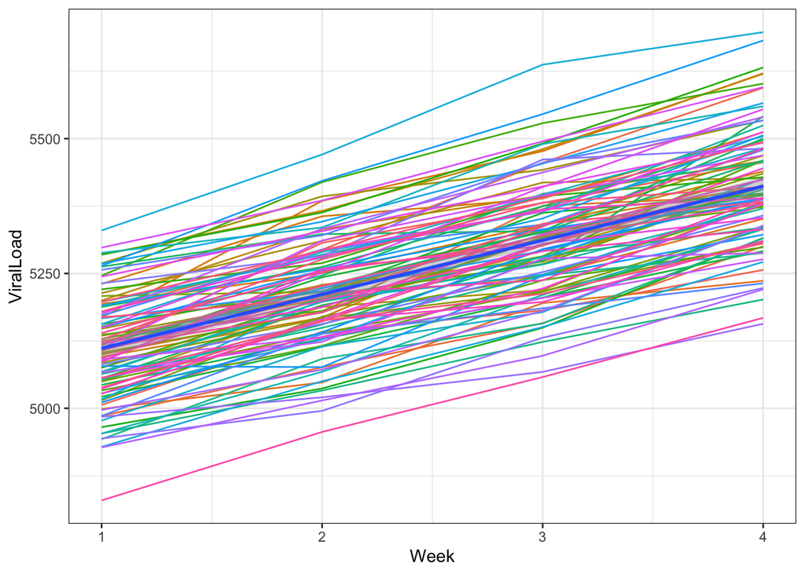

```r
#Visualize Subjects Over Time

dat1 %>%
  ggplot(aes(x = Week,
             y = ViralLoad,
             color = factor(Subject),
             group = Subject)) +
  geom_line() +  # individual trajectory
  geom_smooth(aes(group = 1), method = "lm") +  # overall trend line
  theme_bw() +
  #facet_wrap(~Treatment) +
  theme(legend.position = "none")
```

It seems there is a linear trend in Titexatine changes over time for each subject in both placebo and titexatine. There are 4 time points and two treatment groups: Titexatine group and placebo group. So, I choose to fit a linear mixed effect model with random intercept and slope to perform longitudinal data analysis. Time and treatment and their interaction term are considered as fixed effect.
Statistical model:
$$Y_{ijk} = a + \delta t_{ijk} + a_{i(j)} + d_{i(j)}t_{ijk} + \lambda 1_{[Titexatine]i} + \phi t_{ijk} 1_{[Titexatine]i} + e_{ijk}$$
$Y_{ijk}$: Viral level for treatment i, subject j in time k;
$a$: Fixed intercept;
$\delta$: Fixed slope;
$a_{i(j)}$: Random subject-specific intercept (nested within treatment);
$d_{i(j)}$: Random subject-specific slope (nested within treatment);
$\lambda$: Main effect of Titexatine;
$\phi$: Interaction effect of time and Titexatine;
$e_{ijk}\sim N(0, \sigma_e^2)$: Error term.

## Description of analysis

```r
a <- lmer(ViralLoad ~ Week * Treatment +
            (1 + Week|Treatment:Subject),
          data = dat1)
```

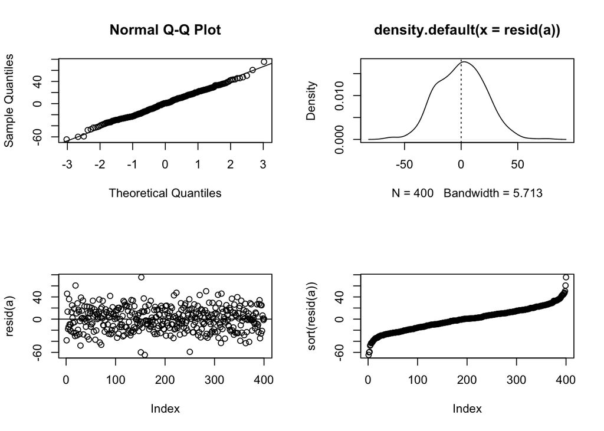

```r
#Check Model Assumptions

#Check normality, homoskedasticity, and for potential outliers of model residuals.
#Normality
par(mfrow = c(2,2)) #Make the plot screen into 4 parts
qqnorm(resid(a)) #Display the 1st plot of the actual response values v the estimated values
qqline(resid(a)) #Makes the expected line of values
plot(density(resid(a))) #Display 2nd plot of distribution of residuals
abline(v=0,lty=3) #Dotted line on the mean=0
#Homoskedasticity
plot(resid(a)) #Display 3rd plot as the distribution of the residuals
abline(h=0) #Straight line along resid=0
#Outliers
plot(sort(resid(a))) #Display 4th
```

Check Model Assumptions: According to the Q-Q plot and density plot, the residuals are normally distributed with equal variance. The residuals are randomly distributed and no obvious outliers. It appears the normality and equal variance assumptions are not violated. Next take a look at the regression summary:

```r
summary(a)
```

```
## Linear mixed model fit by REML. t-tests use Satterthwaite's method [
## lmerModLmerTest]
## Formula: ViralLoad ~ Week * Treatment + (1 + Week | Treatment:Subject)
##    Data: dat1
##
## REML criterion at convergence: 4246.8
##
## Scaled residuals:
##     Min      1Q  Median      3Q     Max
## -2.3801 -0.5596  0.0280  0.5503  2.7815
##
## Random effects:
##  Groups            Name        Variance Std.Dev. Corr
##  Treatment:Subject (Intercept) 9525.6   97.60
##                    Week         251.0   15.84    -0.13
##  Residual                       736.7   27.14
## Number of obs: 400, groups:  Treatment:Subject, 100
##
## Fixed effects:
##                           Estimate Std. Error        df t value Pr(>|t|)
## (Intercept)              5006.4099    14.7293   98.0001 339.895   <2e-16 ***
## Week                      100.5395     2.8513   97.9997  35.261   <2e-16 ***
## TreatmentTitexatine         8.8002    20.6251   98.0001   0.427    0.671
## Week:TreatmentTitexatine   -0.6253     3.9926   97.9997  -0.157    0.876
## ---
## Signif. codes:  0 '***' 0.001 '**' 0.01 '*' 0.05 '.' 0.1 ' ' 1
##
## Correlation of Fixed Effects:
##             (Intr) Week   TrtmnT
## Week        -0.280
## TrtmntTtxtn -0.714  0.200
## Wk:TrtmntTt  0.200 -0.714 -0.280
```

The variances of the random effect are all greater then 0. For fixed effect, Viral load is significantly associated time controlling for treatment (p < 0.01). Treatment does not have a significant effect on viral load over time (p = 0.671). Moreover, treatment does not have a significant impact on the growth of viral load over time (p = 0.876).

## Conclusion

Linear mixed model was conducted to investigate if Titexatine changes viral load over the first few weeks. It appears at a 0.05 significance level, there is no sufficient evidence to support that Titexatine have a significant effect on viral load over time (p = 0.671). Besides, treatment does not have a significant impact on the growth of viral load over time (p = 0.876).

# 2.

## Data Description

We are investigating comparative effectiveness of two interventions that are designed to facilitate physical activity in older women who were diagnosed with a certain degenerative disease. The women were divided into two Groups: A & B; each group received one of the interventions. I have the data on weekly physical activity levels for first few years.

```r
dat2 <- read.csv("AvgWeeklyPA.csv")
sum(is.na(dat2))
```

```
## [1] 0
```

```r
str(dat2)
```

```
## 'data.frame':    180 obs. of  4 variables:
##  $ Subject     : int  1 1 1 1 1 1 2 2 2 2 ...
##  $ Year        : int  1 2 3 4 5 6 1 2 3 4 ...
##  $ Intervention: chr  "A" "A" "A" "A" ...
##  $ AvgWkPA     : num  16.22 13.05 10.96 10.15 8.66 ...
```

```r
dat2$Subject <- as.factor(dat2$Subject)
```

There is no missing values in our dataset.

## Description of model building

I will perform an appropriate linear model analysis to investigate if the interventions are differentially changing the physical activity levels. Not visualize the weekly physical activity levels over time for each subject:

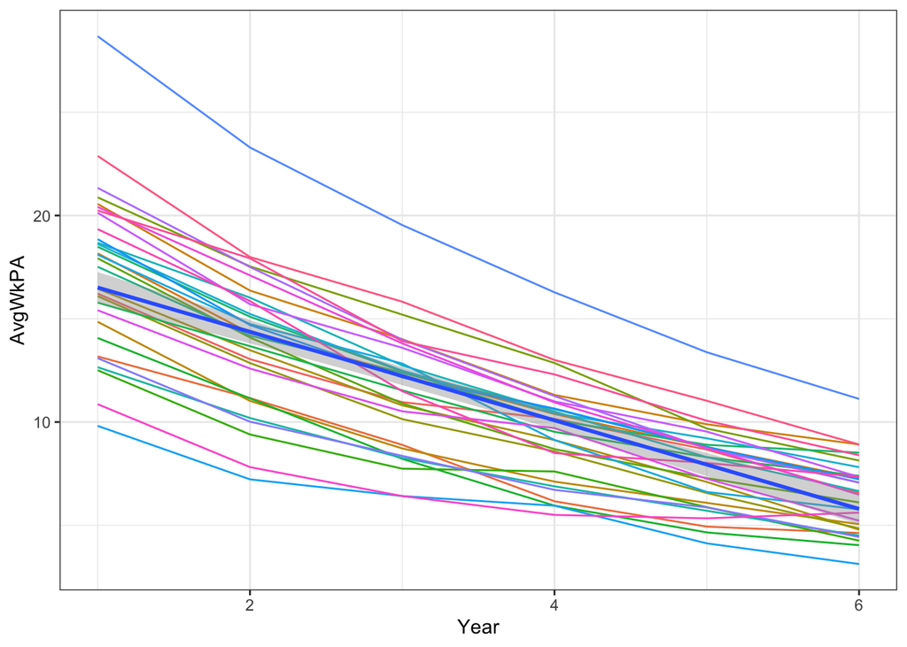

```r
#Visualize Subjects Over Time
dat2 %>%
  ggplot(aes(x = Year,
             y = AvgWkPA,
             color = factor(Subject),
             group = Subject)) +
  geom_line() +  # individual trajectory
  geom_smooth(aes(group = 1), method = "lm") +  # overall trend line
  theme_bw() +
  #facet_wrap(~Intervention) +
  theme(legend.position = "none")
```

It seems there is a quadratic trend in weekly physical activity levels over years. There are 6 time points and two treatment groups. Thus, a linear mixed model with quadratic trend would be conducted for longitudinal analysis.
Statistical model:
$$Y_{ijk} = a + \delta_1 t_{ijk} + \delta_2 t^2_{ijk} + d_{i(j)0} + d_{i(j)1}t_{ijk} + d_{i(j)2}t^2_{ijk} + \lambda_0 1_{[B]i} + \lambda_1 t_{ijk} 1_{[B]i} + \lambda_2 t^2_{ijk} 1_{[B]i} + e_{ijk}$$
$Y_{ijk}$: Weekly physical activity levels for treatment i, subject j in time k;
$a$: Fixed intercept;
$\delta_0, \delta_1, \delta_2$: Fixed coefficients of time;
$d_{i(j)0}, d_{i(j)1}, d_{i(j)2}$: Random subject-specific coefficients of time nested within treatment group;
$\lambda_0$: Main effect of treatment B;
$\lambda_1$: Interaction effect of time and treatment B;
$\lambda_2$: Interaction effect of time$^2$ and treatment B;
$e_{ijk}\sim N(0, \sigma_e^2)$: Error term.

## Description of analysis

```r
b <- lmer(AvgWkPA ~ Year +
            Intervention +
            I(Year^2) +
            Year:Intervention +
            I(Year^2):Intervention +
            (Year + I(Year^2)|Subject) ,
          data = dat2)
```

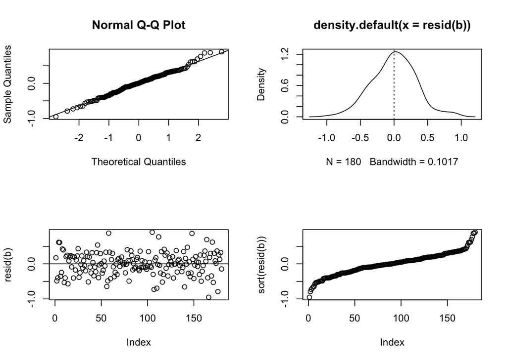

```r
#Check Model Assumptions

#Check normality, homoskedasticity, and for potential outliers of model residuals.
#Normality
par(mfrow = c(2,2)) #Make the plot screen into 4 parts
qqnorm(resid(b)) #Display the 1st plot of the actual response values v the estimated values
qqline(resid(b)) #Makes the expected line of values
plot(density(resid(b))) #Display 2nd plot of distribution of residuals
abline(v=0,lty=3) #Dotted line on the mean=0
#Homoskedasticity
plot(resid(b)) #Display 3rd plot as the distribution of the residuals
abline(h=0) #Straight line along resid=0
#Outliers
plot(sort(resid(b))) #Display 4th
```

Check Model Assumptions: According to the Q-Q plot and density plot, the residuals are normally distributed with equal variance. The residuals are randomly distributed and no obvious outliers. It appears the normality and equal variance assumptions are not violated. Next take a look at the regression summary:

```r
summary(b)
```

```
## Linear mixed model fit by REML. t-tests use Satterthwaite's method [
## lmerModLmerTest]
## Formula: AvgWkPA ~ Year + Intervention + I(Year^2) + Year:Intervention +
##     I(Year^2):Intervention + (Year + I(Year^2) | Subject)
##    Data: dat2
##
## REML criterion at convergence: 457.2
##
## Scaled residuals:
##      Min       1Q   Median       3Q      Max
## -2.25723 -0.52907  0.00474  0.48353  2.13300
##
## Random effects:
##  Groups   Name        Variance  Std.Dev. Corr
##  Subject  (Intercept) 20.933209 4.57528
##           Year         0.769378 0.87714  -0.82
##           I(Year^2)    0.007677 0.08762   0.41 -0.84
##  Residual              0.178552 0.42255
## Number of obs: 180, groups:  Subject, 30
##
## Fixed effects:
##                          Estimate Std. Error        df t value Pr(>|t|)
## (Intercept)             19.909352   1.239371 28.027425  16.064 1.14e-15 ***
## Year                    -3.627274   0.269116 28.021250 -13.478 9.05e-14 ***
## InterventionB            1.713077   1.697079 28.027428   1.009    0.321
## I(Year^2)                0.227446   0.029832 28.009145   7.624 2.63e-08 ***
## Year:InterventionB      -0.264519   0.368503 28.021256  -0.718    0.479
## InterventionB:I(Year^2)  0.008667   0.040850 28.009149   0.212    0.834
## ---
## Signif. codes:  0 '***' 0.001 '**' 0.01 '*' 0.05 '.' 0.1 ' ' 1
##
## Correlation of Fixed Effects:
##             (Intr) Year   IntrvB I(Y^2) Yr:InB
## Year        -0.780
## InterventnB -0.730  0.570
## I(Year^2)    0.405 -0.870 -0.296
## Yr:IntrvntB  0.570 -0.730 -0.780  0.636
## IntB:I(Y^2) -0.296  0.636  0.405 -0.730 -0.870
## convergence code: 0
## Model failed to converge with max|grad| = 0.00276226 (tol = 0.002, component 1)
```